# 1 Experimento - Passeio Aleatória

[figure not shown]

Figure 1.1: O andar de um bebado é usado como alegoria para representar a ideia de uma caminhada aleatoria.

## 1.1 Objetivo

Introduzir os visitantes da mostra a idéia de caminhada aleatória e estimular o pensamento probabilistico dos mesmos.

## 1.2 Descrição

Suponha que o movimento de um certo ponto no plano pode ser descrito da seguinte maneira.

Uma moeda honesta é lançada, caso dê cara o ponto avança em diagonal para a direita, caso dê coroa ela avança em diagonal para a esquerda, onde cada lançamento pode ser considerado um “passo”.

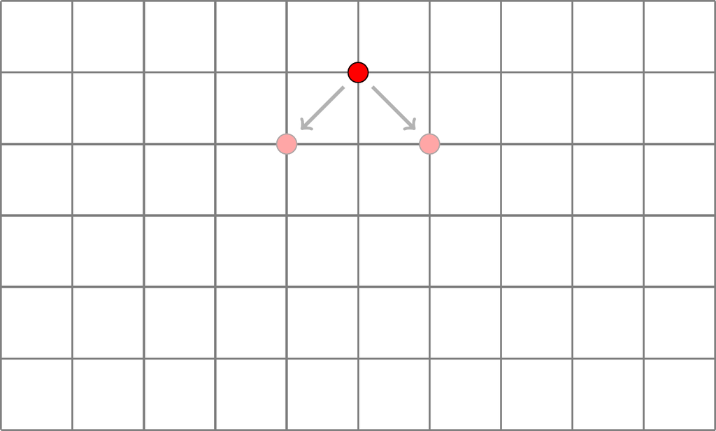

Sabendo disso qual será a posição final desse ponto após 4 passos ?

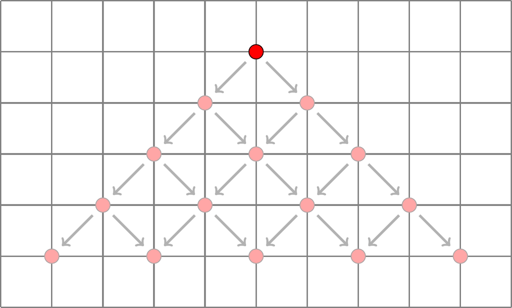

## 1.3 Construção

Para esse experimento são necessarios:

1. Um “marcador de posição”, item qualquer que possa ser utilizado para marcar a posição atual.
2. O desenho de uma malha quadriculada ou para ser mais intuitivo somente o desenho dos caminhos possiveis.
3. Uma moeda honesta.

## 1.4 Execução

Uma sugestão de passo a passo é:

1. Perguntar ao participante em qual das possiveis posições finais o marcador irá terminar.
2. Em seguida posicionar o marcador na origem e lançar a moeda.
3. Dependendo do resultado o marcado será movido para uma das proximas possições.
4. Assim sucessivamente até a moeda ter sido lançada quatro vezes.
5. Ao final é explicada a ideia por traz do experimento e a teoria, por exemplo o porque da moeda acabar mais nas posições centrais do que nas bordas.

## 1.5 Teoria

### 1.5.1 Resultado Intuitivo

Denotando as cinco últimas posições como 1,2,3,4,5 vindo da esquerda para a direta e utilizando a notação ${\scriptstyle C}$ para cara e ${\scriptstyle \bar{C}}$ para coroa.

Observe que, para o ponto terminar na posição 1, é necessário que ocorra uma sequência de 4 coroas consecutivas, ou seja, o resultado ${ \scriptstyle \bar{C}\bar{C}\bar{C}\bar{C}}$. Da mesma forma, para o ponto terminar na posição 5, é necessário que ocorra o resultado $\scriptstyle CCCC$.

Generalizando essa ideia, temos:

- Resultados que te levam a posição 1: ${\scriptstyle \bar{C}\bar{C}\bar{C}\bar{C}}$.
- Resultados que te levam a posição 2: $\scriptstyle C\bar{C}\bar{C}\bar{C}$, $\scriptstyle \bar{C}C\bar{C}\bar{C}$, $\scriptstyle \bar{C}\bar{C}C\bar{C}$ e $\scriptstyle \bar{C}\bar{C}\bar{C}C$.
- Resultados que te levam a posição 3: $\scriptstyle \bar{C}\bar{C}CC$, $\scriptstyle \bar{C}C\bar{C}C$, $\scriptstyle \bar{C}CC\bar{C}$, $\scriptstyle CC\bar{C}\bar{C}$, $\scriptstyle C\bar{C}C\bar{C}$ e $\scriptstyle C\bar{C}\bar{C}C$.
- Resultados que te levam a posição 4: $\scriptstyle \bar{C}CCC$, $\scriptstyle C\bar{C}CC$, $\scriptstyle CC\bar{C}C$ e $\scriptstyle CCC\bar{C}$.
- Resultados que te levam a posição 5: $\scriptstyle CCCC$.

Aqui estão todos os 16 possíveis resultados ao lançar uma moeda quatro vezes. Como a moeda é justa, todos esses resultados são igualmente prováveis.

Considere o evento “moeda terminar na posição $\scriptstyle X$” que será denotado por $\scriptstyle PX$.

Calculando as probabilidades, temos:

$\scriptstyle P(\text{P1}) = P(\bar{C}\bar{C}\bar{C}\bar{C}) = (1/2)^4 = 1/16$

$\scriptstyle P(\text{P2}) = P(C\bar{C}\bar{C}\bar{C} \ \cup \ \bar{C}C\bar{C}\bar{C} \ \cup \ \bar{C}\bar{C}C\bar{C} \ \cup \ \bar{C}\bar{C}\bar{C}C) = 4 \times (1/2)^4 = 4/16$

$\scriptstyle P(\text{P3}) = P(\bar{C}\bar{C}CC \ \cup \ \bar{C}C\bar{C}C \ \cup \ \bar{C}CC\bar{C} \ \cup \ CC\bar{C}\bar{C} \ \cup \ C\bar{C}C\bar{C} \ \cup \ C\bar{C}\bar{C}C) = 6 \times (1/2)^4 = 6/16$

$\scriptstyle P(\text{P4}) = P(\bar{C}CCC \ \cup \ C\bar{C}CC \ \cup \ CC\bar{C}C \ \cup \ CCC\bar{C}) = 4 \times (1/2)^4 = 4/16$

$\scriptstyle P(\text{P5}) = P(CCCC) = (1/2)^4 = 1/16$

Logo é evidente ao observarmos a distribuição das probabilidades que realmente a probabilidade do ponto terminar nas posições centrais é maior.

### 1.5.2 Distribuição binomial

Como a moeda é honesta temos que os possíveis movimentos com mesmo número de passos são equiprováveis, logo o que vai determinar a probabilidade do ponto terminar em certa posição final vai ser as dado pelas diferentes formas que ele tem para chegar lá vezes $1/2^n$ onde $n$ é o número de passos.

O número de formas que o ponto pode chegar na k-ésima posição final, $0 \leq k \leq n$, após n passos é dada pelo coeficiente binomial $n \choose k$.

Logo a probabilidade de apos n passos o ponto termine na posição k é dada por

$$P(k,n) = {n \choose k} \frac{1}{2^n} \ , \ 0 \leq k \leq n$$

Que é o formato de uma distribuição binomial com parâmetros $(n, p = 1/2)$, logo podemos concluir que com um n grande a distribuição de probabilidades das posições finais se assemelham com uma distribuição normal centrada no valor $n/2$.

Logo o ponto possui maior probabilidade de visitar as posições centrais do que visitar as posições nos extremos.

> É importante ressaltar que qualquer adição ou mudança na explicação da teoria para torná-la mais clara e acessível aos participantes é bem-vinda. Diversos são os visitantes da mostra e a explicação que é óbvia para alguns pode ser confusa para outros.

## 1.6 Aplicação prática

A teoria da caminhada aleatória é uma ferramenta matemática amplamente empregada em diversas áreas para modelar processos estocásticos ou sistemas nos quais a mudança de estado é governada por aleatoriedade.

Na física, por exemplo, temos o conceito de movimento browniano. Em resumo, o movimento browniano descreve o movimento aleatório de uma partícula suspensa em algum tipo de fluido. Nesse contexto, a partícula realiza uma caminhada aleatória tridimensional, sendo influenciada por colisões e interações imprevisíveis com as moléculas do fluido circundante.

## 1.7 Referências e leituras complementares

**Paul Meyer**. Probabilidade - Aplicações à Estatística, 2ª ed. capítulo 12.3. “Aproximação Normal da Distribuição Binomial”.

**Weisstein, Eric W**. “Random Walk–1-Dimensional.”, disponível em: https://mathworld.wolfram.com/RandomWalk1-Dimensional.html

**Michael Fowler**. “The One-Dimensional Random Walk”, disponível em: https://galileo.phys.virginia.edu/classes/152.mf1i.spring02/RandomWalk.htm